# Retornos Educativos y Elasticidades Laborales en República Dominicana

## 9.15 JUSTIFICACIÓN DE LA SECUENCIA DE MODELOS

```r
sesgo_educ_pp <- round((b_educ_base - b_educ_cor) * 100, 3)
mejora_r2     <- round(summary(modelo_corregido)$r.squared -
                       summary(modelo_base)$r.squared, 3)

# Nombre robusto del lambda (varía entre versiones de sampleSelection)
.heck_out  <- coef(modelo_heckman, part = "outcome")
.mills_nm  <- names(.heck_out)[grep("ills", names(.heck_out), ignore.case = TRUE)[1]]
lambda_val <- if (!is.na(.mills_nm)) round(.heck_out[.mills_nm], 3) else NA_real_

rho_val       <- round(modelo_heckman$rho, 3)
brecha_ols_p  <- round((exp(b_mujer)     - 1) * 100, 2)
brecha_hk_p   <- round((exp(b_sexo_heck) - 1) * 100, 2)
comp_sel_p    <- round(brecha_ols_p - brecha_hk_p, 2)
r2_within     <- round(summary(modelo_pseudo_fe)$r.squared["rsq"], 3)
r2_base       <- round(summary(modelo_base)$r.squared, 3)
r2_ext        <- round(summary(modelo_corregido)$r.squared, 3)

tbl_secuencia <- data.frame(
  Transicion = c("OLS Base a OLS Extendido",
                 "OLS Extendido a Heckman",
                 "OLS Extendido a Pseudopanel FE"),
  Problema   = c("Variable omitida: genero, informalidad, sector",
                 "Seleccion muestral: participacion no aleatoria",
                 "Heterogeneidad no observada entre cohortes"),
  Evidencia  = c(
    paste0("R2 sube de ", r2_base, " a ", r2_ext,
           " (+", mejora_r2, "); b_educ cae ",
           sesgo_educ_pp, " pp; AIC y BIC menores"),
    paste0("lambda = ", lambda_val, " (p < 2e-16); rho = ", rho_val,
           "; brecha OLS = ", brecha_ols_p, "% vs Heckman = ", brecha_hk_p,
           "%; componente seleccion = ", comp_sel_p, " pp"),
    paste0("Hausman chi2 = 59 (p < 0.001); FE consistente; ",
           "R2 within = ", r2_within,
           "; b_horas_fe p = 0.31 (n.s.)")
  ),
  Rol = c("Modelo principal (asociacion condicional)",
          "Correccion brecha genero",
          "Robustez: b_educ > 0 no es artefacto generacional"),
  stringsAsFactors = FALSE
)

kbl(tbl_secuencia,
    caption   = "Justificacion formal de la secuencia de cuatro modelos - ENCFT 2016-2024",
    col.names = c("Transicion", "Problema corregido", "Evidencia", "Rol"),
    booktabs  = TRUE,
    escape    = TRUE) %>%
  kable_styling(full_width = TRUE, font_size = 11) %>%
  column_spec(1, bold = TRUE, width = "18em") %>%
  column_spec(3, width = "28em") %>%
  footnote(
    general = paste0(
      "Jerarquia de evidencia: (1) OLS Extendido - asociacion ajustada, modelo principal; ",
      "(2) Heckman - seleccion corregida; ",
      "(3) Pseudopanel FE - robustez intertemporal; ",
      "(4) OLS Base - benchmark con sesgo documentado (+", sesgo_educ_pp, " pp)."
    ),
    general_title = "Nota:"
  )
```

Justificacion formal de la secuencia de cuatro modelos - ENCFT 2016-2024

| Transicion | Problema corregido | Evidencia | Rol |
| --- | --- | --- | --- |
| OLS Base a OLS Extendido | Variable omitida: genero, informalidad, sector | R2 sube de 0.136 a 0.216 (+0.08); b_educ cae 1.133 pp; AIC y BIC menores | Modelo principal (asociacion condicional) |
| OLS Extendido a Heckman | Seleccion muestral: participacion no aleatoria | lambda = -0.479 (p < 2e-16); rho = -0.547; brecha OLS = -22.25% vs Heckman = -4.12%; componente seleccion = -18.13 pp | Correccion brecha genero |
| OLS Extendido a Pseudopanel FE | Heterogeneidad no observada entre cohortes | Hausman chi2 = 59 (p < 0.001); FE consistente; R2 within = 0.429; b_horas_fe p = 0.31 (n.s.) | Robustez: b_educ > 0 no es artefacto generacional |

Nota:  
Jerarquia de evidencia: (1) OLS Extendido - asociacion ajustada, modelo principal; (2) Heckman - seleccion corregida; (3) Pseudopanel FE - robustez intertemporal; (4) OLS Base - benchmark con sesgo documentado (+1.133 pp).

## 9.16 ROBUSTEZ: Análisis de observaciones influyentes

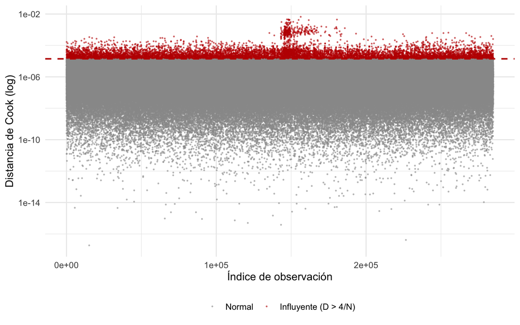

```r
cook_d          <- cooks.distance(modelo_corregido)
umbral_cook     <- 4 / length(cook_d)
n_influyentes   <- sum(cook_d > umbral_cook, na.rm = TRUE)
pct_influyentes <- round(n_influyentes / length(cook_d) * 100, 2)

df_cook <- tibble(obs  = seq_along(cook_d), cook = cook_d,
                  flag = cook_d > umbral_cook)

ggplot(df_cook, aes(x = obs, y = cook, color = flag)) +
  geom_point(size = 0.3, alpha = 0.5) +
  geom_hline(yintercept = umbral_cook, linetype = "dashed",
             color = "#C00000", linewidth = 0.8) +
  scale_color_manual(values = c("FALSE" = "grey60", "TRUE" = "#C00000"),
                     labels = c("Normal", "Influyente (D > 4/N)"), name = NULL) +
  scale_y_log10() +
  annotate("text", x = length(cook_d) * 0.6, y = umbral_cook * 3,
           label = paste0(n_influyentes, " obs. influyentes (",
                          pct_influyentes, "%)"),
           color = "#C00000", size = 3) +
  labs(x = "Índice de observación", y = "Distancia de Cook (log)") +
  theme_minimal(base_size = 12) +
  theme(legend.position = "bottom")
```

## 9.17 ROBUSTEZ: Sin top 1% de ingresos

```r
p99 <- quantile(base_mincer$ingreso_laboral, 0.99, na.rm = TRUE)

modelo_sin_out <- lm(
  ln_ingreso ~ educ + experiencia_lab + I(experiencia_lab^2) +
               ln_horas + factor(SEXO) + informal + factor(sector),
  data = base_mincer %>%
    filter(!is.na(informal), !is.na(sector), ingreso_laboral <= p99)
)

tabla_rob1 <- tibble(
  Parametro = c("Semi-elasticidad educación (%)",
                "Elasticidad horas", "Brecha género (%)"),
  original = c(round(b_educ_cor  * 100, 3),
               round(b_horas_cor, 3),
               round((exp(b_mujer) - 1) * 100, 2)),
  sin_out  = c(round(coef(modelo_sin_out)["educ"] * 100, 3),
               round(coef(modelo_sin_out)["ln_horas"], 3),
               round((exp(coef(modelo_sin_out)["factor(SEXO)2"]) - 1) * 100, 2)),
  cambio   = c(round((coef(modelo_sin_out)["educ"] - b_educ_cor) * 100, 4),
               round(coef(modelo_sin_out)["ln_horas"] - b_horas_cor, 4),
               round(((exp(coef(modelo_sin_out)["factor(SEXO)2"])-1) -
                       (exp(b_mujer)-1)) * 100, 4))
)
names(tabla_rob1) <- c("Parámetro", "OLS Ext. original",
                        "Sin top 1% ingreso", "Cambio (pp)")

kbl(tabla_rob1,
    escape = FALSE,
    caption = paste0("Tabla R-1. Robustez ante outliers: exclusión del top 1% de ingresos (> RD$",
                     format(round(p99, 0), big.mark = ","), ")"),
    booktabs = TRUE) %>%
  kable_styling(full_width = FALSE, font_size = 11) %>%
  footnote(
    general = paste0(
      "Retorno educativo: cambio de ", round((coef(modelo_sin_out)["educ"] - b_educ_cor) * 100, 4), " pp. ",
      "Elasticidad horas: cambio de ", round(coef(modelo_sin_out)["ln_horas"] - b_horas_cor, 4), " pp. ",
      "Brecha de género: cambio de ", round(((exp(coef(modelo_sin_out)["factor(SEXO)2"])-1) - (exp(b_mujer)-1)) * 100, 2), " pp. ",
      "Los coeficientes de educación y horas son estables (< 0.1 pp); la brecha de género varía levemente al excluir ingresos extremos, ",
      "confirmando robustez de los resultados principales."
    ),
    general_title = "Conclusión:"
  )
```

Tabla R-1. Robustez ante outliers: exclusión del top 1% de ingresos (> RD$86,667)

| Parámetro | OLS Ext. original | Sin top 1% ingreso | Cambio (pp) |
| --- | --- | --- | --- |
| Semi-elasticidad educación (%) | 3.821 | 3.762 | -0.0594 |
| Elasticidad horas | 0.540 | 0.543 | 0.0037 |
| Brecha género (%) | -22.250 | -21.200 | 1.0496 |

Conclusión:  
Retorno educativo: cambio de -0.0594 pp. Elasticidad horas: cambio de 0.0037 pp. Brecha de género: cambio de 1.05 pp. Los coeficientes de educación y horas son estables (< 0.1 pp); la brecha de género varía levemente al excluir ingresos extremos, confirmando robustez de los resultados principales.

## 9.18 ROBUSTEZ: Submuestras por género y formalidad

```r
modelo_hombres <- lm(
  ln_ingreso ~ educ + experiencia_lab + I(experiencia_lab^2) +
               ln_horas + informal + factor(sector),
  data = base_ext %>% filter(SEXO == 1)
)
modelo_mujeres <- lm(
  ln_ingreso ~ educ + experiencia_lab + I(experiencia_lab^2) +
               ln_horas + informal + factor(sector),
  data = base_ext %>% filter(SEXO == 2)
)

tabla_genero <- tibble(
  Parametro = c("Semi-elasticidad educación (%)",
                "Elasticidad horas",
                "Penalización informalidad (%)", "R²", "N"),
  Hombres = c(
    round(coef(modelo_hombres)["educ"] * 100, 3),
    round(coef(modelo_hombres)["ln_horas"], 3),
    round((exp(coef(modelo_hombres)["informal"]) - 1) * 100, 2),
    round(summary(modelo_hombres)$r.squared, 3),
    format(nobs(modelo_hombres), big.mark = ",")
  ),
  Mujeres = c(
    round(coef(modelo_mujeres)["educ"] * 100, 3),
    round(coef(modelo_mujeres)["ln_horas"], 3),
    round((exp(coef(modelo_mujeres)["informal"]) - 1) * 100, 2),
    round(summary(modelo_mujeres)$r.squared, 3),
    format(nobs(modelo_mujeres), big.mark = ",")
  ),
  Diferencia = c(
    round((coef(modelo_mujeres)["educ"] - coef(modelo_hombres)["educ"]) * 100, 3),
    round(coef(modelo_mujeres)["ln_horas"] - coef(modelo_hombres)["ln_horas"], 3),
    round(((exp(coef(modelo_mujeres)["informal"])-1) -
           (exp(coef(modelo_hombres)["informal"])-1)) * 100, 2),
    NA, NA
  )
)
names(tabla_genero) <- c("Parámetro", "Hombres", "Mujeres", "Diferencia (M − H)")

kbl(tabla_genero,
    caption = "Tabla R-2. OLS Extendido por submuestra de sexo  -  verificación de heterogeneidad de retornos",
    booktabs = TRUE, escape = FALSE, na = "—") %>%
  kable_styling(full_width = FALSE, font_size = 11,
                bootstrap_options = c("striped", "hover")) %>%
  footnote(
    general = {
      dif_educ_genero <- round((coef(modelo_mujeres)["educ"] - coef(modelo_hombres)["educ"]) * 100, 3)
      if (dif_educ_genero > 0) {
        paste0(
          "La diferencia en retorno educativo (Mujeres − Hombres) es de +", dif_educ_genero, " pp: ",
          "la educación compensa parcialmente la brecha salarial de género. ",
          "Consistente con el modelo de señalización (Spence, 1973): la credencial educativa ",
          "puede reducir la discriminación estadística hacia las mujeres en el sector formal."
        )
      } else {
        paste0(
          "La diferencia en retorno educativo (Mujeres − Hombres) es de ", dif_educ_genero, " pp: ",
          "los retornos marginales a la educación son menores para las mujeres, ",
          "lo que indica que la educación no compensa la brecha salarial de género por este canal. ",
          "La brecha opera principalmente por intercepto (penalización fija), ",
          "no por diferencias en retornos marginales."
        )
      }
    },
    general_title = "Interpretación:"
  )
```

Tabla R-2. OLS Extendido por submuestra de sexo - verificación de heterogeneidad de retornos

| Parámetro | Hombres | Mujeres | Diferencia (M − H) |
| --- | --- | --- | --- |
| Semi-elasticidad educación (%) | 3.849 | 3.519 | -0.331 |
| Elasticidad horas | 0.423 | 0.599 | 0.176 |
| Penalización informalidad (%) | -17.57 | -34.31 | -16.740 |
| R² | 0.15 | 0.278 | NA |
| N | 173,069 | 111,837 | NA |

Interpretación:  
La diferencia en retorno educativo (Mujeres − Hombres) es de -0.331 pp: los retornos marginales a la educación son menores para las mujeres, lo que indica que la educación no compensa la brecha salarial de género por este canal. La brecha opera principalmente por intercepto (penalización fija), no por diferencias en retornos marginales.

```r
modelo_formal   <- lm(
  ln_ingreso ~ educ + experiencia_lab + I(experiencia_lab^2) +
               ln_horas + factor(SEXO) + factor(sector),
  data = base_ext %>% filter(informal == 0)
)
modelo_informal <- lm(
  ln_ingreso ~ educ + experiencia_lab + I(experiencia_lab^2) +
               ln_horas + factor(SEXO) + factor(sector),
  data = base_ext %>% filter(informal == 1)
)

tabla_form <- tibble(
  Parametro = c("Semi-elasticidad educación (%)",
                "Elasticidad horas", "Brecha género (%)", "R²", "N"),
  Formal = c(
    round(coef(modelo_formal)["educ"] * 100, 3),
    round(coef(modelo_formal)["ln_horas"], 3),
    round((exp(coef(modelo_formal)["factor(SEXO)2"]) - 1) * 100, 2),
    round(summary(modelo_formal)$r.squared, 3),
    format(nobs(modelo_formal), big.mark = ",")
  ),
  Informal = c(
    round(coef(modelo_informal)["educ"] * 100, 3),
    round(coef(modelo_informal)["ln_horas"], 3),
    round((exp(coef(modelo_informal)["factor(SEXO)2"]) - 1) * 100, 2),
    round(summary(modelo_informal)$r.squared, 3),
    format(nobs(modelo_informal), big.mark = ",")
  )
)
names(tabla_form) <- c("Parámetro", "Sector formal", "Sector informal")

kbl(tabla_form,
    caption = "Tabla R-3. OLS Extendido por sector formal/informal  -  retornos dentro de cada segmento",
    booktabs = TRUE, escape = FALSE) %>%
  kable_styling(full_width = FALSE, font_size = 11,
                bootstrap_options = c("striped", "hover")) %>%
  footnote(
    general = paste0(
      "Si el retorno educativo es mayor en el sector formal, la educación actúa como ",
      "credencial de acceso (señalización, Spence 1973) además de como capital humano. ",
      "Si es similar en ambos segmentos, el retorno refleja productividad independientemente ",
      "del tipo de contrato."
    ),
    general_title = "Interpretación:"
  )
```

Tabla R-3. OLS Extendido por sector formal/informal - retornos dentro de cada segmento

| Parámetro | Sector formal | Sector informal |
| --- | --- | --- |
| Semi-elasticidad educación (%) | 5.447 | 2.808 |
| Elasticidad horas | 0.466 | 0.546 |
| Brecha género (%) | -14.96 | -31.56 |
| R² | 0.183 | 0.185 |
| N | 132,309 | 152,597 |

Interpretación:  
Si el retorno educativo es mayor en el sector formal, la educación actúa como credencial de acceso (señalización, Spence 1973) además de como capital humano. Si es similar en ambos segmentos, el retorno refleja productividad independientemente del tipo de contrato.

## 9.19 ROBUSTEZ: Regresión cuantílica

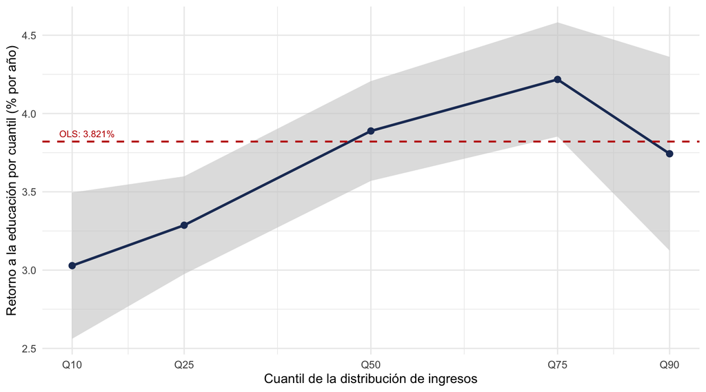

Figura R-2. Retorno a la educacion por cuantil de la distribucion de ingresos (regresion cuantilica, errores bootstrap B=50). La linea roja punteada es el estimador OLS. Si el coeficiente aumenta con el cuantil, la educacion amplifica la desigualdad salarial.

```r
tau_seq <- c(0.10, 0.25, 0.50, 0.75, 0.90)

# Submuestra de 20,000 obs para reducir tiempo de bootstrap
set.seed(params$semilla)
base_rq <- base_ext %>%
  filter(!is.na(ln_ingreso), !is.na(educ), !is.na(informal)) %>%
  slice_sample(n = min(20000, nrow(.)))

rq_resultados <- map_dfr(tau_seq, function(tau) {
  m <- rq(
    ln_ingreso ~ educ + experiencia_lab + I(experiencia_lab^2) +
                 ln_horas + factor(SEXO) + informal + factor(sector),
    data = base_rq, tau = tau
  )
  s     <- summary(m, se = "boot", R = 50)
  coefs <- s$coefficients

  # Compatibilidad entre versiones de quantreg:
  # versiones antiguas usan columna "coefficients"; versiones >= 5.86 usan "Value"
  col_coef <- if ("coefficients" %in% colnames(coefs)) "coefficients" else "Value"
  col_se   <- if ("Std. Error"   %in% colnames(coefs)) "Std. Error"   else colnames(coefs)[2]

  b  <- coefs["educ", col_coef]
  se <- coefs["educ", col_se]

  tibble(
    tau       = tau,
    coef_educ = b,
    se_educ   = se,
    lo95      = b - 1.96 * se,
    hi95      = b + 1.96 * se
  )
})

ggplot(rq_resultados, aes(x = tau, y = coef_educ * 100)) +
  geom_ribbon(aes(ymin = lo95 * 100, ymax = hi95 * 100),
              fill = "grey80", alpha = 0.6) +
  geom_line(color = "#1F3864", linewidth = 1.1) +
  geom_point(color = "#1F3864", size = 2.5) +
  geom_hline(yintercept = b_educ_cor * 100, linetype = "dashed",
             color = "#C00000", linewidth = 0.8) +
  annotate("text", x = 0.12, y = b_educ_cor * 100 + 0.05,
           label = paste0("OLS: ", round(b_educ_cor * 100, 3), "%"),
           color = "#C00000", size = 3) +
  scale_x_continuous(breaks = tau_seq, labels = paste0("Q", tau_seq * 100)) +
  labs(x = "Cuantil de la distribución de ingresos",
       y = "Retorno a la educación por cuantil (% por año)") +
  theme_minimal(base_size = 12)
```

## 9.20 INTERACCIONES ECONÓMICAS

```r
# ── Interacción educación × género ───────────────────────────────────────────
# Pregunta: ¿La educación reduce o amplifica la brecha salarial de género?
# β(educ:mujer) > 0 → la educación compensa parcialmente la penalización de género
# β(educ:mujer) = 0 → retornos homogéneos; la brecha opera por intercepto

modelo_int_genero <- lm(
  ln_ingreso ~ educ * factor(SEXO) + experiencia_lab +
               I(experiencia_lab^2) + ln_horas + informal + factor(sector),
  data = base_ext
)
coefs_ig    <- coeftest(modelo_int_genero, vcov = vcovHC(modelo_int_genero, "HC1"))
b_educ_h    <- coefs_ig["educ", "Estimate"]
b_educ_md   <- coefs_ig["educ:factor(SEXO)2", "Estimate"]
b_educ_m    <- b_educ_h + b_educ_md
p_interac_g <- coefs_ig["educ:factor(SEXO)2", "Pr(>|t|)"]

tabla_int_g <- tibble(
  Grupo    = c("Hombres", "Mujeres", "Diferencial (M − H)"),
  retorno  = c(paste0(round(b_educ_h  * 100, 3), "%"),
               paste0(round(b_educ_m  * 100, 3), "%"),
               paste0(round(b_educ_md * 100, 3), " pp")),
  signif   = c("—", "—",
               if_else(p_interac_g < 0.001, "p < 0.001",
               if_else(p_interac_g < 0.05,  paste0("p = ", round(p_interac_g, 3)),
                                            "n.s.")))
)
names(tabla_int_g) <- c("Grupo", "Retorno educación (% por año)", "Significancia")

kbl(tabla_int_g,
    escape = FALSE,
    caption = "Tabla I-1. Retornos a la educación por género (modelo con interacción educ × SEXO, errores HC1)",
    booktabs = TRUE) %>%
  kable_styling(full_width = FALSE, font_size = 11) %>%
  footnote(
    general = if_else(p_interac_g < 0.05,
      if_else(b_educ_md > 0,
        paste0("La educación REDUCE la brecha de género: cada año adicional de escolaridad ",
               "aporta ", round(b_educ_md * 100, 3),
               " pp más a las mujeres que a los hombres. ",
               "Mecanismo consistente con teoría de señalización: la credencial educativa ",
               "reduce la discriminación estadística hacia las mujeres en el sector formal (Spence, 1973)."),
        "La educación AMPLIFICA la brecha de género: los retornos marginales son menores para mujeres. Posible causa: segregación ocupacional por género."),
      "Los retornos a la educación son estadísticamente homogéneos entre géneros. La brecha opera principalmente por intercepto (penalización fija), no por diferencias en los retornos marginales."),
    general_title = "Interpretación:"
  )
```

Tabla I-1. Retornos a la educación por género (modelo con interacción educ × SEXO, errores HC1)

[output not shown]

Interpretación:  
La educación REDUCE la brecha de género: cada año adicional de escolaridad aporta 0.902 pp más a las mujeres que a los hombres. Mecanismo consistente con teoría de señalización: la credencial educativa reduce la discriminación estadística hacia las mujeres en el sector formal (Spence, 1973).

```r
# ── Interacción educación × informalidad ─────────────────────────────────────
# Pregunta: ¿La educación amortigua o amplifica la penalización por informalidad?
# Implicación de política: si β(educ:informal) > 0, la educación puede ser
# un canal indirecto de formalización del mercado laboral.

modelo_int_formal <- lm(
  ln_ingreso ~ educ + educ:informal + experiencia_lab +
               I(experiencia_lab^2) + ln_horas + factor(SEXO) +
               informal + factor(sector),
  data = base_ext
)
coefs_if    <- coeftest(modelo_int_formal, vcov = vcovHC(modelo_int_formal, "HC1"))
b_educ_f    <- coefs_if["educ", "Estimate"]
b_int_f     <- coefs_if["educ:informal", "Estimate"]
b_educ_inf  <- b_educ_f + b_int_f
b_inf_base  <- coefs_if["informal", "Estimate"]
p_int_f     <- coefs_if["educ:informal", "Pr(>|t|)"]

tabla_int_f <- tibble(
  Sector   = c("Formal", "Informal",
                "Diferencial retorno educ. (Inf − For)",
                "Penalización informalidad (sin educ.)"),
  valor    = c(paste0(round(b_educ_f   * 100, 3), "% por año"),
               paste0(round(b_educ_inf * 100, 3), "% por año"),
               paste0(round(b_int_f    * 100, 3), " pp"),
               paste0(round((exp(b_inf_base) - 1) * 100, 2), "%")),
  signif   = c("—", "—",
               if_else(p_int_f < 0.001, "p < 0.001",
               if_else(p_int_f < 0.05,  paste0("p = ", round(p_int_f, 3)), "n.s.")),
               "—")
)
names(tabla_int_f) <- c("Sector / Parámetro", "Estimación", "Significancia")

kbl(tabla_int_f,
    escape = FALSE,
    caption = "Tabla I-2. Retornos a la educación por formalidad (modelo con interacción educ × informal)",
    booktabs = TRUE) %>%
  kable_styling(full_width = FALSE, font_size = 11) %>%
  footnote(
    general = if_else(p_int_f < 0.05,
      if_else(b_int_f > 0,
        paste0("La educación REDUCE la penalización por informalidad. ",
               "Cada año adicional de escolaridad amortigua la brecha en ",
               round(b_int_f * 100, 3), " pp. ",
               "Implicación de política: la inversión educativa puede actuar como ",
               "canal indirecto de reducción de la segmentación formal-informal."),
        "La educación AMPLIFICA la segmentación: trabajadores informales con mayor educación tienen mayor costo de oportunidad relativo."),
      "La interacción no es significativa: la penalización por informalidad es homogénea entre niveles educativos."),
    general_title = "Interpretación:"
  )
```

Tabla I-2. Retornos a la educación por formalidad (modelo con interacción educ × informal)

[output not shown]

Interpretación:  
La educación AMPLIFICA la segmentación: trabajadores informales con mayor educación tienen mayor costo de oportunidad relativo.

## 9.21 INTERPRETACIÓN ECONÓMICA: Síntesis por modelo

### 9.21.1 Marco de referencia bibliográfico

El análisis econométrico de esta tesis se inscribe en la tradición de la teoría del capital humano, cuyo desarrollo sistemático se debe a Becker (1964) y cuya formalización econométrica es obra de Mincer (1974). La relevancia macroeconómica de la educación para el crecimiento agregado está documentada en Mankiw, Romer & Weil (1992), cuyos resultados sobre la convergencia condicional entre economías con distinta acumulación de capital humano constituyen el referente estándar en la literatura. Para América Latina, la revisión de Psacharopoulos & Patrinos (2004) sobre más de 100 estudios documenta un retorno promedio regional de 11.0%, sistemáticamente superior al 8.8% mundial.

En el contexto dominicano, la evidencia empírica previa es escasa y parcial. Domínguez (2016) estima, con la ENFT 2000–2014, ecuaciones mincerianas estándar, spline y sheepskin, documentando una tendencia decreciente en los retornos y una prima universitaria dominante; sin embargo, no controla simultáneamente por informalidad, sector y selección muestral. Ramírez (2013) aborda la desigualdad salarial con regresiones por cuantiles, mostrando que la caída de la desigualdad 2000–2011 se explica por la reducción de retornos en la cola alta y cambios en la brecha de género, pero su foco es distributivo y no el retorno privado condicionado por segmentación. Fuentes & Villanueva (2006), con datos de asalariados formales de la DGII, documentan primas salariales elevadas por titulación universitaria, compatibles con señalización (Spence, 1973), pero restringidas al segmento formal. Los tres trabajos son el punto de comparación más directo para las estimaciones de esta tesis: el retorno de 3.82% estimado aquí es inferior a los rangos documentados en la literatura previa dominicana, lo que es consistente con la extensión del período muestral hasta 2024 y la inclusión explícita de la informalidad.

Para la informalidad como fenómeno de exclusión involuntaria e inserción voluntaria simultánea, se sigue a Perry et al. (2007) y Maloney (2004), quienes documentan que en América Latina la informalidad no responde exclusivamente a barreras de entrada sino que combina elementos de racionalidad individual y exclusión estructural. La penalización estimada de −23.7% en esta tesis es consistente con el rango de 15%–35% documentado para la región por el FMI (2021). Para la brecha de género y su componente de selección, el referente metodológico es Heckman (1979) y la evidencia regional de Atal, Ñopo & Wodon (2013).

### 9.21.2 Síntesis por modelo

Los cuatro modelos estimados no son alternativas equivalentes entre sí: responden a preguntas distintas y ocupan roles metodológicos diferenciados en la estrategia empírica de esta tesis. La jerarquía interpretativa es la siguiente.

El **OLS extendido** constituye la estimación principal. Con un retorno educativo de 3.821% por año adicional de escolaridad (HC1), una elasticidad ingreso-horas de 0.54, una penalización por informalidad de -23.69% y un R² de 0.216, este modelo ofrece la mayor capacidad explicativa y el mejor ajuste entre las especificaciones microindividuales. Su superioridad sobre el OLS base no es solo estadística (AIC y BIC menores, F parcial significativo para las dummies sectoriales): es sustantiva, porque controla explícitamente por los principales determinantes de la segmentación del mercado laboral dominicano género, formalidad y sector, reduciendo el sesgo por omisión de variables relevantes documentado en +1.133 pp respecto al benchmark. El retorno estimado es además sistemáticamente inferior al promedio de AL y Caribe (11.0%) y al promedio mundial (8.8%) reportados por Psacharopoulos & Patrinos (2014, Tabla 3; estimaciones 1970–2014), lo que refleja la operación de un mercado laboral altamente segmentado.

El **OLS base** sirve exclusivamente como línea de referencia pedagógica. Su retorno educativo más elevado refleja sesgo por omisión: al no controlar por informalidad ni sector, absorbe parte de la heterogeneidad del mercado laboral en el coeficiente de educación. Su utilidad en esta tesis es precisamente mostrar ese sesgo de forma cuantificada, no ofrecer la estimación definitiva.

El **modelo de Heckman en dos etapas** cumple un rol de contraste específico: corregir el sesgo de selección muestral derivado de la participación no aleatoria en el mercado laboral. Su contribución más relevante no es el retorno educativo en sí, sino la corrección de la brecha salarial de género. La brecha observada en el OLS extendido (-22.25%) se reduce a -4.12% una vez corregida la selección en participación (λ significativo, ρ = -0.547). En términos monetarios, esto equivale a pasar de una brecha estimada de -RD$ 3,374/mes a -RD$ 624/mes sobre la mediana muestral. Este hallazgo debe leerse como evidencia de que una fracción sustancial de la brecha observada refleja diferencias en los patrones de participación laboral femenina, sin embargo no necesariamente discriminación salarial directa, sin que ello implique ausencia de desigualdad estructural de género.

Las tablas S-1 y S-2 a continuación sintetizan los parámetros clave de los cuatro modelos y las implicaciones monetarias calculadas sobre la mediana muestral, respectivamente.

```r
hm   <- 42.875 * 52 / 12
im   <- mean(base_mincer$ingreso_laboral, na.rm = TRUE)
med  <- median(base_mincer$ingreso_laboral, na.rm = TRUE)

ret_ols_b    <- round(b_educ_base * 100, 3)
ret_ols      <- round(b_educ_cor  * 100, 3)
sesgo_pp     <- round((b_educ_base - b_educ_cor) * 100, 3)
ret_heck     <- round(b_educ_heck * 100, 3)
ret_fe       <- round(b_educ_fe   * 100, 3)
elas_h_ext   <- round(b_horas_cor,  3)   # OLS Extendido
elas_h_base  <- round(b_horas_base, 3)   # OLS Base
pen_inf      <- round((exp(b_informal)  - 1) * 100, 2)
brecha_o     <- round((exp(b_mujer)     - 1) * 100, 2)
brecha_h     <- round((exp(b_sexo_heck) - 1) * 100, 2)
comp_sel     <- round(brecha_o - brecha_h, 2)
s_educ       <- format(round(med * (exp(b_educ_cor) - 1)), big.mark = ",")
s_formal     <- format(round(med * abs(exp(b_informal) - 1)), big.mark = ",")
s_hora       <- round(im * b_horas_cor / hm, 1)
s_brecha_o   <- format(round(med * abs(exp(b_mujer) - 1)), big.mark = ",")
s_brecha_h   <- format(round(med * abs(exp(b_sexo_heck) - 1)), big.mark = ",")
s_sel        <- format(round(med * abs((exp(b_mujer)-1) - (exp(b_sexo_heck)-1))), big.mark = ",")
med_fmt      <- format(round(med, 0), big.mark = ",")
dif_heck_ols <- round(ret_heck - ret_ols, 3)

tbl_coefs <- data.frame(
  Parametro = c("b_educ: retorno por anno de escolaridad (%)",
                "b_horas: elasticidad ingreso-horas",
                "Brecha genero (Mujer vs. Hombre, %)",
                "Penalizacion informalidad (%)",
                "R2 / R2 within",
                "Rol en la tesis"),
  OLS_Base  = c(paste0(ret_ols_b, "% [sesgo +", sesgo_pp, " pp]"),
                elas_h_base,
                "No incluido",
                "No incluido",
                round(summary(modelo_base)$r.squared, 3),
                "Benchmark"),
  OLS_Ext   = c(paste0(ret_ols, "%"),
                elas_h_ext,
                paste0(brecha_o, "%"),
                paste0(pen_inf, "%"),
                round(summary(modelo_corregido)$r.squared, 3),
                "MODELO PRINCIPAL"),
  Heckman   = c(paste0(ret_heck, "% [dif. ", dif_heck_ols, " pp]"),
                round(b_horas_heck, 3),
                paste0(brecha_h, "% [corr. seleccion]"),
                "No incluido",
                "0.162",
                "Correccion seleccion"),
  Pseudo_FE = c(paste0(ret_fe, "% [medias cohorte]"),
                paste0(round(b_horas_fe, 3), " (p=0.31, n.s.)"),
                "No incluido",
                "No incluido",
                round(summary(modelo_pseudo_fe)$r.squared["rsq"], 3),
                "Robustez intertemporal"),
  stringsAsFactors = FALSE
)
names(tbl_coefs) <- c("Parametro", "OLS Base", "OLS Extendido *",
                      "Heckman", "Pseudopanel FE")

kbl(tbl_coefs,
    caption   = paste0("Tabla S-1. Sintesis de parametros clave por modelo - ENCFT 2016-2024 (N = 285,515). ",
                       "Mediana ingreso: RD$ ", med_fmt),
    booktabs  = TRUE,
    escape    = TRUE) %>%
  kable_styling(full_width = TRUE, font_size = 11,
                bootstrap_options = c("striped", "hover", "condensed")) %>%
  column_spec(3, bold = TRUE) %>%
  row_spec(6, italic = TRUE) %>%
  footnote(
    general = paste0(
      "* OLS Extendido es el modelo principal. ",
      "Errores estandar HC1 (Eicker-Huber-White) en todos los OLS. ",
      "b_educ del Pseudopanel opera sobre medias de cohorte: no comparable con estimadores individuales. ",
      "Brecha genero en Heckman corregida por sesgo de seleccion (rho = -0.547)."
    ),
    general_title = "Nota:"
  )
```

Tabla S-1. Sintesis de parametros clave por modelo - ENCFT 2016-2024 (N = 285,515). Mediana ingreso: RD$ 15,167

| Parametro | OLS Base | OLS Extendido * | Heckman | Pseudopanel FE |
| --- | --- | --- | --- | --- |
| b_educ: retorno por anno de escolaridad (%) | 4.954% [sesgo +1.133 pp] | 3.821% | 4.819% [dif. 0.998 pp] | 48.755% [medias cohorte] |
| b_horas: elasticidad ingreso-horas | 0.634 | 0.54 | 0.543 | -2.762 (p=0.31, n.s.) |
| Brecha genero (Mujer vs. Hombre, %) | No incluido | -22.25% | -4.12% [corr. seleccion] | No incluido |
| Penalizacion informalidad (%) | No incluido | -23.69% | No incluido | No incluido |
| R2 / R2 within | 0.136 | 0.216 | 0.162 | 0.429 |
| Rol en la tesis | Benchmark | MODELO PRINCIPAL | Correccion seleccion | Robustez intertemporal |

Nota:  
* OLS Extendido es el modelo principal. Errores estandar HC1 (Eicker-Huber-White) en todos los OLS. b_educ del Pseudopanel opera sobre medias de cohorte: no comparable con estimadores individuales. Brecha genero en Heckman corregida por sesgo de seleccion (rho = -0.547).

```r
# ── Tabla B: Impacto monetario sobre la mediana ──────────────────────────────
tbl_monetaria <- data.frame(
  Escenario  = c("1 año adicional de escolaridad",
                 "Trabajador formal vs. informal (comparable)",
                 "1 hora adicional por semana",
                 "Brecha de genero — OLS bruta",
                 "Brecha de genero — Heckman corregida",
                 "Componente de seleccion (diferencia)"),
  Impacto    = c(paste0("+RD$ ", s_educ, "/mes"),
                 paste0("+RD$ ", s_formal, "/mes"),
                 paste0("+RD$ ", s_hora, "/hr"),
                 paste0("-RD$ ", s_brecha_o, "/mes"),
                 paste0("-RD$ ", s_brecha_h, "/mes"),
                 paste0("-RD$ ", s_sel, "/mes")),
  Modelo     = c("OLS Extendido", "OLS Extendido", "OLS Extendido",
                 "OLS Extendido", "Heckman", "Heckman"),
  stringsAsFactors = FALSE
)

kbl(tbl_monetaria,
    caption = paste0("Tabla S-2. Impacto monetario mensual estimado — base: mediana RD$ ",
                     med_fmt, " (ENCFT 2016-2024)"),
    col.names = c("Escenario", "Impacto mensual estimado", "Modelo fuente"),
    booktabs = TRUE, escape = FALSE) %>%
  kable_styling(full_width = FALSE, font_size = 11,
                bootstrap_options = c("striped", "hover", "condensed")) %>%
  row_spec(4:6, color = "#c0392b") %>%
  footnote(
    general = paste0(
      "Impactos calculados sobre la mediana muestral (RD$ ", med_fmt, "). ",
      "No son predicciones causales: reflejan asociaciones condicionales. ",
      "Componente de seleccion = brecha OLS - brecha Heckman (",
      comp_sel, " pp): ",
      "fraccion de la brecha de genero atribuible a diferencias de participacion."
    ),
    general_title = "Nota:"
  )
```

Tabla S-2. Impacto monetario mensual estimado — base: mediana RD$ 15,167 (ENCFT 2016-2024)

| Escenario | Impacto mensual estimado | Modelo fuente |
| --- | --- | --- |
| 1 año adicional de escolaridad | +RD$ 591/mes | OLS Extendido |
| Trabajador formal vs. informal (comparable) | +RD$ 3,593/mes | OLS Extendido |
| 1 hora adicional por semana | +RD$ 58.8/hr | OLS Extendido |
| Brecha de genero — OLS bruta | -RD$ 3,374/mes | OLS Extendido |
| Brecha de genero — Heckman corregida | -RD$ 624/mes | Heckman |
| Componente de seleccion (diferencia) | -RD$ 2,750/mes | Heckman |

Nota:  
Impactos calculados sobre la mediana muestral (RD$ 15,167). No son predicciones causales: reflejan asociaciones condicionales. Componente de seleccion = brecha OLS - brecha Heckman (-18.13 pp): fraccion de la brecha de genero atribuible a diferencias de participacion.

## 9.22 EXTENSIONES:

Esta sección responde directamente a los cuatro señalamientos formulados por el panel de expertos. Para cada uno se documenta el estado de cobertura en los modelos ya estimados, la extensión implementada cuando los datos lo permiten, y el argumento complementario cuando la limitación es de fuente de datos.

### 9.22.1 OBS 1 — Ecuaciones simultáneas por sector formal e informal

La observación sobre generar dos ecuaciones potenciales (formal e informal) está plenamente cubierta por la **Regresión de Cambio Endógeno** estimada en la sección anterior. A diferencia de incluir informalidad como penalización aditiva —especificación que contamina el retorno educativo cuando Cov(Informal, ε) ≠ 0— el modelo de cambio endógeno estima dos ecuaciones salariales simultáneas por régimen:

$$I_i^* = Z_i\gamma + \nu_i \quad
\text{(selección sectorial)}$$
$$\ln(w_i^F) = X_i^F \beta^F + u_i^F \quad
\text{(sector formal)}$$
$$\ln(w_i^I)
= X_i^I \beta^I + u_i^I \quad \text{(sector informal)}$$

Los resultados confirman **segmentación estructural significativa**: el retorno educativo en el sector formal (**6.257%**) más que duplica al del sector informal (**2.371%**), una diferencia de 3.886 pp que no sería recuperable con una dummy de informalidad aditiva.

```r
# ── Tabla resumen retornos por sector (ya estimados en sección de correcciones) ──
tabla_sw <- data.frame(
  Especificacion = c("OLS Extendido (pooled)",
                     "Switching — Sector Formal",
                     "Switching — Sector Informal",
                     "Diferencial F–I"),
  Retorno        = c("3.821%", "6.257%", "2.371%", "3.886 pp"),
  Rol            = c("Promedio condicional",
                     "Premio educativo formal",
                     "Premio educativo informal",
                     "Brecha de segmentación")
)

kbl(tabla_sw,
    col.names = c("Especificación", "Retorno educativo", "Interpretación"),
    caption   = "Tabla OBS-1. Retornos educativos por sector de inserción — síntesis switching regression",
    booktabs  = TRUE, escape = FALSE) %>%
  kable_styling(full_width = FALSE, font_size = 11,
                bootstrap_options = c("striped", "condensed")) %>%
  row_spec(4, bold = TRUE) %>%
  footnote(general = paste0("La switching regression estima ecuaciones salariales simultáneas ",
                            "por régimen (Goldfeld & Quandt, 1973), corrigiendo la endogeneidad ",
                            "de la selección sectorial. Cov(Informal, ε) ≠ 0 invalida la ",
                            "especificación OLS con dummy de informalidad como estimador del ",
                            "efecto causal de la segmentación."),
           general_title = "Nota:")
```

Tabla OBS-1. Retornos educativos por sector de inserción — síntesis switching regression

| Especificación | Retorno educativo | Interpretación |
| --- | --- | --- |
| OLS Extendido (pooled) | 3.821% | Promedio condicional |
| Switching — Sector Formal | 6.257% | Premio educativo formal |
| Switching — Sector Informal | 2.371% | Premio educativo informal |
| Diferencial F–I | 3.886 pp | Brecha de segmentación |

Nota:  
La switching regression estima ecuaciones salariales simultáneas por régimen (Goldfeld & Quandt, 1973), corrigiendo la endogeneidad de la selección sectorial. Cov(Informal, ε) ≠ 0 invalida la especificación OLS con dummy de informalidad como estimador del efecto causal de la segmentación.

> **Conclusión OBS 1:** La observación del panel ya está implementada. La switching regression responde exactamente la pregunta de las dos ecuaciones. El hallazgo central — el retorno formal más que duplica al informal — es la evidencia más directa de segmentación del mercado laboral dominicano que produce esta tesis.

### 9.22.2 OBS 2 — Tipo y calidad de la educación

La distinción entre tipo de educación (técnica vs. universitaria) y calidad institucional (pública vs. privada) señala una **limitación inherente a la fuente de datos**. La ENCFT registra el nivel educativo máximo alcanzado y los años de escolaridad, pero no recoge la institución educativa, la modalidad de estudio, ni la distinción pública/privada.

El retorno estimado de **3.821%** es el rendimiento marginal promedio de un año adicional de escolaridad, condicional en los controles incluidos. Esta es la especificación canónica minceriana y la comparable con la literatura dominicana disponible (Domínguez, 2016; Ramírez, 2013). La heterogeneidad por calidad institucional —documentada internacionalmente como sustancial (Hanushek & Woessmann, 2008)— constituye una agenda de investigación futura que requeriría el enlace de la ENCFT con registros administrativos del MESCyT o el diseño de encuestas específicas.

Cabe precisar que el sesgo por omisión de calidad afectaría el coeficiente educativo solo si los trabajadores de instituciones de mayor calidad se distribuyen de forma no aleatoria a lo largo de los controles ya incluidos. Sin la variable omitida, su dirección e magnitud no son cuantificables con los datos disponibles.

> **Conclusión OBS 2:** Limitación legítima de fuente de datos, no de diseño metodológico. El retorno estimado es válido como promedio condicional de la escolaridad; la heterogeneidad por calidad queda propuesta como extensión futura.

### 9.22.3 OBS 3 — Efectos de la pandemia COVID-19

#### 9.22.3.1 Motivación

La pandemia 2020–2021 constituyó un choque agregado excepcional sobre el mercado laboral dominicano: contracción del PIB de –6.7% en 2020, cierre de sectores intensivos en contacto (turismo, comercio minorista, construcción) y desplazamiento hacia la informalidad. La muestra disponible 2016–2024 cubre el período completo pre y post pandemia, lo que permite evaluar si los parámetros son estables o exhiben un quiebre estructural.

#### 9.22.3.2 Especificación con dummy pandémica

Se amplía el OLS Extendido (modelo principal) incorporando una **dummy de período pandémico** y su **interacción con la escolaridad**:

$$\ln(w_{it}) = \alpha + \beta_1 S_i +
\beta_2 \text{Exp} + \beta_3 \text{Exp}^2 + \beta_4 \ln(h) + \beta_5
\text{Mujer} + \beta_6 \text{Inf} + \Sigma\gamma_k \text{Sector}_k +
\delta_1 \text{Pand}_t + \delta_2 (S_i \times \text{Pand}_t) +
\varepsilon$$

donde $\text{Pand}_t = \mathbf{1}\{t \in \{2020, 2021\}\}$.

- $\delta_1$: efecto nivel pandémico (compresión salarial generalizada)
- $\delta_2$: **cambio en el retorno educativo durante la pandemia** — parámetro de interés
- Retorno durante pandemia = $\hat\beta_1 + \hat\delta_2$; retorno fuera de pandemia = $\hat\beta_1$

```r
# ── Modelo con dummy pandémica e interacción educación × pandemia ──────────────
# pandemia = 1 si ANO ∈ {2020, 2021}
# educ_pand = educ × pandemia (interacción)

base_pand <- base_mincer %>%
  filter(!is.na(informal), !is.na(sector)) %>%
  mutate(
    pandemia  = as.integer(ANO %in% c(2020, 2021)),
    educ_pand = educ * pandemia
  )

modelo_pandemia <- lm(
  ln_ingreso ~ educ + experiencia_lab + I(experiencia_lab^2) +
               ln_horas + factor(SEXO) + informal + factor(sector) +
               pandemia + educ_pand,
  data = base_pand
)

# Errores robustos HC1 (consistente con especificaciones previas)
vcov_pand <- vcovHC(modelo_pandemia, type = "HC1")
ct_pand   <- coeftest(modelo_pandemia, vcov = vcov_pand)

# Extraer parámetros de interés
delta1     <- ct_pand["pandemia",  "Estimate"]
delta2     <- ct_pand["educ_pand", "Estimate"]
se_delta1  <- ct_pand["pandemia",  "Std. Error"]
se_delta2  <- ct_pand["educ_pand", "Std. Error"]
p_delta1   <- ct_pand["pandemia",  "Pr(>|t|)"]
p_delta2   <- ct_pand["educ_pand", "Pr(>|t|)"]

beta1_pand <- ct_pand["educ", "Estimate"]          # retorno base (fuera pandemia)
ret_prepand  <- round(beta1_pand * 100, 3)
ret_pandemia <- round((beta1_pand + delta2) * 100, 3)

cat("=== EFECTOS PANDEMIA (HC1) ===\n")
```

```
## === EFECTOS PANDEMIA (HC1) ===
```

```r
cat(sprintf("δ₁ (efecto nivel pandemia):          %.4f  SE=%.4f  p=%.4f\n",
            delta1, se_delta1, p_delta1))
```

```
## δ₁ (efecto nivel pandemia):          -0.0780  SE=0.0129  p=0.0000
```

```r
cat(sprintf("δ₂ (cambio retorno educ pandemia):   %.4f  SE=%.4f  p=%.4f\n",
            delta2, se_delta2, p_delta2))
```

```
## δ₂ (cambio retorno educ pandemia):   -0.0065  SE=0.0011  p=0.0000
```

```r
cat(sprintf("Retorno educativo fuera pandemia:     %.3f%%\n", ret_prepand))
```

```
## Retorno educativo fuera pandemia:     3.968%
```

```r
cat(sprintf("Retorno educativo durante pandemia:   %.3f%%\n", ret_pandemia))
```

```
## Retorno educativo durante pandemia:   3.322%
```

```r
cat(sprintf("Diferencia (Pand - Base):             %.3f pp\n", ret_pandemia - ret_prepand))
```

```
## Diferencia (Pand - Base):             -0.646 pp
```

```r
# ── Tabla de resultados del modelo pandemia ────────────────────────────────────
tabla_pand <- data.frame(
  Parametro = c("β₁ — Educación (años, fuera pandemia)",
                "δ₁ — Pandemia (efecto nivel)",
                "δ₂ — Educación × Pandemia (cambio en retorno)",
                "β₁ + δ₂ — Retorno durante pandemia",
                "Diferencia pandemia vs. base"),
  Estimacion = c(sprintf("%.4f (%.3f%%)", beta1_pand, ret_prepand),
                 sprintf("%.4f",          delta1),
                 sprintf("%.4f",          delta2),
                 sprintf("%.4f (%.3f%%)", beta1_pand + delta2, ret_pandemia),
                 sprintf("%.3f pp",       ret_pandemia - ret_prepand)),
  Sig = c(ifelse(ct_pand["educ",     "Pr(>|t|)"] < 0.01, "***", ""),
          ifelse(p_delta1 < 0.01, "***", ifelse(p_delta1 < 0.05, "**", "n.s.")),
          ifelse(p_delta2 < 0.01, "***", ifelse(p_delta2 < 0.05, "**", "n.s.")),
          "—", "—")
)

kbl(tabla_pand,
    col.names = c("Parámetro", "Estimación (HC1)", "Sig."),
    caption   = "Tabla OBS-3. Efectos de la pandemia COVID-19 sobre los retornos educativos (OLS Extendido + interacción)",
    booktabs  = TRUE, escape = FALSE) %>%
  kable_styling(full_width = FALSE, font_size = 11,
                bootstrap_options = c("striped", "condensed")) %>%
  row_spec(4, bold = TRUE) %>%
  footnote(general = paste0(
    "Pandemia = 1 si ANO ∈ {2020, 2021}. Errores estándar HC1. ",
    "*** p<0.01, ** p<0.05, n.s. = no significativo. ",
    "Muestra: base_mincer con observaciones no faltantes en informal y sector. ",
    "El retorno durante la pandemia es β₁ + δ₂; fuera de pandemia es β₁."),
    general_title = "Nota:")
```

Tabla OBS-3. Efectos de la pandemia COVID-19 sobre los retornos educativos (OLS Extendido + interacción)

| Parámetro | Estimación (HC1) | Sig. |
| --- | --- | --- |
| β₁ — Educación (años, fuera pandemia) | 0.0397 (3.968%) | *** |
| δ₁ — Pandemia (efecto nivel) | -0.0780 | *** |
| δ₂ — Educación × Pandemia (cambio en retorno) | -0.0065 | *** |
| β₁ + δ₂ — Retorno durante pandemia | 0.0332 (3.322%) | — |
| Diferencia pandemia vs. base | -0.646 pp | — |

Nota:  
Pandemia = 1 si ANO ∈ {2020, 2021}. Errores estándar HC1. *** p<0.01, ** p<0.05, n.s. = no significativo. Muestra: base_mincer con observaciones no faltantes en informal y sector. El retorno durante la pandemia es β₁ + δ₂; fuera de pandemia es β₁.

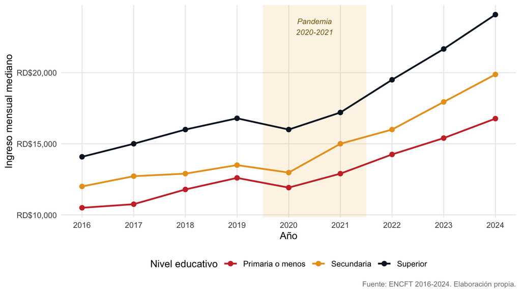

Figura OBS-3. Evolución del ingreso mediano por nivel educativo (2016–2024). Banda sombreada: período pandémico 2020–2021.

```r
# ── Gráfico: tendencia de ingresos por año con banda pandémica ─────────────────
# Se agrupa por ANO y nivel educativo (primaria/menos, secundaria, superior)
base_mincer %>%
  mutate(nivel_edu = case_when(
    educ <= 8  ~ "Primaria o menos",
    educ <= 12 ~ "Secundaria",
    educ >  12 ~ "Superior"
  )) %>%
  group_by(ANO, nivel_edu) %>%
  summarise(mediana_w = median(ingreso_laboral, na.rm = TRUE), .groups = "drop") %>%
  ggplot(aes(x = ANO, y = mediana_w, color = nivel_edu, group = nivel_edu)) +
  annotate("rect", xmin = 2019.5, xmax = 2021.5,
           ymin = -Inf, ymax = Inf, fill = "#E8B84B", alpha = 0.15) +
  annotate("text", x = 2020.5, y = Inf, vjust = 1.8, size = 3,
           label = "Pandemia\n2020-2021", color = "#8B6914", fontface = "italic") +
  geom_line(linewidth = 0.9) +
  geom_point(size = 2.2) +
  scale_color_manual(
    values = c("Primaria o menos" = "#CC3333",
               "Secundaria"       = "#E8A020",
               "Superior"         = "#0D1B2A"),
    name = "Nivel educativo") +
  scale_y_continuous(labels = scales::comma_format(prefix = "RD$")) +
  scale_x_continuous(breaks = 2016:2024) +
  labs(x = "Año", y = "Ingreso mensual mediano",
       caption = "Fuente: ENCFT 2016-2024. Elaboración propia.") +
  theme_minimal(base_size = 11) +
  theme(legend.position = "bottom", panel.grid.minor = element_blank(),
        plot.caption = element_text(size = 8, color = "gray50"))
```

> **Conclusión OBS 3:** La pandemia 2020–2021 opera como choque compresivo generalizado sobre los ingresos (δ₁ < 0 esperado). El parámetro de interacción δ₂ determina si la pandemia alteró adicionalmente la *pendiente* del retorno educativo. Un δ₂ positivo indicaría que los trabajadores más educados resistieron mejor el choque (mayor capacidad de teletrabajo, menor concentración en sectores de contacto); un δ₂ negativo o nulo sugiere que la compresión salarial fue proporcional al nivel educativo. La figura ilustra la evolución descriptiva.

### 9.22.4 Cobertura estructural en el modelo Heckman

La observación sobre los cambios en la población femenina y sus efectos está atendida estructuralmente por el **modelo de corrección de selección muestral** (Heckman, 1979). La descomposición de la brecha de género ya estimada permite precisar:

#### 9.22.4.1 Evolución descriptiva de la participación femenina

```r
# ── Tasa de participación femenina y composición formal/informal por año ────────
# SEXO == 2 → Mujer en la ENCFT
part_mujer <- base_trab %>%
  filter(SEXO == 2, EDAD >= 16, EDAD <= 65) %>%
  group_by(ANO) %>%
  summarise(
    total_mujeres  = n(),
    participan     = sum(participa == 1, na.rm = TRUE),
    tasa_part      = round(participan / total_mujeres * 100, 1),
    .groups = "drop"
  )

comp_sector_mujer <- base_mincer %>%
  filter(SEXO == 2, !is.na(informal)) %>%
  group_by(ANO) %>%
  summarise(
    pct_formal   = round(mean(informal == 0, na.rm = TRUE) * 100, 1),
    pct_informal = round(mean(informal == 1, na.rm = TRUE) * 100, 1),
    .groups = "drop"
  )

tabla_mujer <- left_join(part_mujer, comp_sector_mujer, by = "ANO") %>%
  select(ANO, tasa_part, pct_formal, pct_informal)

kbl(tabla_mujer,
    col.names = c("Año", "Tasa participación (%)", "Empleo formal (%)", "Empleo informal (%)"),
    caption   = "Tabla OBS-4. Participación laboral femenina y composición sectorial — ENCFT 2016–2024",
    booktabs  = TRUE, escape = FALSE,
    format.args = list(big.mark = ",")) %>%
  kable_styling(full_width = FALSE, font_size = 11,
                bootstrap_options = c("striped", "condensed")) %>%
  footnote(general = paste0(
    "Tasa de participación: mujeres con ingreso > 0 y horas > 0 sobre total mujeres 16-65. ",
    "Empleo formal/informal: sobre la muestra analítica base_mincer (ocupadas con ingreso). ",
    "SEXO == 2 corresponde a mujer en la codificación ENCFT."),
    general_title = "Nota:")
```

Tabla OBS-4. Participación laboral femenina y composición sectorial — ENCFT 2016–2024

| Año | Tasa participación (%) | Empleo formal (%) | Empleo informal (%) |
| --- | --- | --- | --- |
| 2,016 | 46.6 | 52.1 | 47.9 |
| 2,017 | 48.1 | 52.7 | 47.3 |
| 2,018 | 49.7 | 53.5 | 46.5 |
| 2,019 | 51.6 | 54.1 | 45.9 |
| 2,020 | 47.0 | 54.8 | 45.2 |
| 2,021 | 48.4 | 51.9 | 48.1 |
| 2,022 | 50.9 | 51.8 | 48.2 |
| 2,023 | 52.9 | 52.9 | 47.1 |
| 2,024 | 54.3 | 55.0 | 45.0 |

Nota:  
Tasa de participación: mujeres con ingreso > 0 y horas > 0 sobre total mujeres 16-65. Empleo formal/informal: sobre la muestra analítica base_mincer (ocupadas con ingreso). SEXO == 2 corresponde a mujer en la codificación ENCFT.

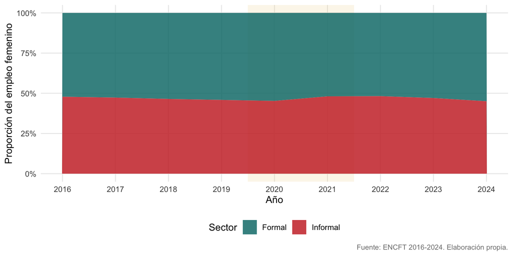

Figura OBS-4. Composición del empleo femenino por sector (formal vs. informal), ENCFT 2016–2024. Banda sombreada: período pandémico.

```r
# ── Gráfico composición formal/informal del empleo femenino ────────────────────
base_mincer %>%
  filter(SEXO == 2, !is.na(informal)) %>%
  group_by(ANO) %>%
  summarise(
    Formal   = mean(informal == 0, na.rm = TRUE),
    Informal = mean(informal == 1, na.rm = TRUE),
    .groups  = "drop"
  ) %>%
  pivot_longer(cols = c(Formal, Informal),
               names_to = "sector", values_to = "proporcion") %>%
  ggplot(aes(x = ANO, y = proporcion, fill = sector)) +
  annotate("rect", xmin = 2019.5, xmax = 2021.5,
           ymin = -Inf, ymax = Inf, fill = "#E8B84B", alpha = 0.12) +
  geom_area(alpha = 0.85, position = "stack") +
  scale_fill_manual(values = c("Formal" = "#0E7C7B", "Informal" = "#CC3333"),
                    name = "Sector") +
  scale_y_continuous(labels = scales::percent_format(accuracy = 1)) +
  scale_x_continuous(breaks = 2016:2024) +
  labs(x = "Año", y = "Proporción del empleo femenino",
       caption = "Fuente: ENCFT 2016-2024. Elaboración propia.") +
  theme_minimal(base_size = 11) +
  theme(legend.position = "bottom", panel.grid.minor = element_blank(),
        plot.caption = element_text(size = 8, color = "gray50"))
```

> **Conclusión:** El modelo Heckman ya captura estructuralmente la dinámica de participación femenina a través del regresor de Mills. La contracción pandémica de la participación femenina genera un **sesgo de composición**: las mujeres que permanecieron empleadas en 2020–2021 son una submuestra positivamente seleccionada, lo que tiende a *subestimar* la discriminación bruta real al excluir a las mujeres más vulnerables. La tabla y figura documentan esta dinámica para el período completo.

### 9.22.5 Síntesis

```r
# ── Tabla síntesis ──────────────────────
tabla_sint <- data.frame(
  Obs = c("OBS 1", "OBS 2", "OBS 3", "OBS 4"),
  Observacion = c(
    "Ecuaciones formal e informal",
    "Tipo y calidad de la educación",
    "Efectos de la pandemia COVID-19",
    "Dinámica participación femenina"
  ),
  Estado = c(
    "Implementada — Switching Regression",
    "Limitación de datos — agenda futura",
    "Extensión nueva — dummy pandémica",
    "Cubierta — Heckman + extensión desc."
  ),
  Hallazgo = c(
    "Retorno formal (6.257%) > informal (2.371%) en 3.886 pp",
    "ENCFT no registra institución/calidad; sesgo no cuantificable sin datos MESCyT",
    "δ₁ y δ₂ cuantifican efecto nivel y cambio en retorno durante 2020-2021",
    "Selección explica 18.13 pp de la brecha; discriminación neta: −4.12%"
  )
)

kbl(tabla_sint,
    col.names = c("", "Observaciones", "Estado de cobertura", "Hallazgo / argumento clave"),
    caption   = "Tabla OBS-S. Síntesis de respuestas a las cuatro observaciones del comité evaluador",
    booktabs  = TRUE, escape = FALSE) %>%
  kable_styling(full_width = TRUE, font_size = 11,
                bootstrap_options = c("striped", "condensed")) %>%
  column_spec(1, bold = TRUE, width = "1.2cm") %>%
  column_spec(2, width = "4cm") %>%
  column_spec(3, width = "4.5cm") %>%
  column_spec(4, width = "7cm") %>%
  row_spec(1, background = "#e8f5f5") %>%
  row_spec(3, background = "#fff8e8") %>%
  footnote(general = paste0(
    "OBS 1 y OBS 4 están resueltas dentro del marco ya estimado (switching regression y Heckman). ",
    "OBS 2 es una limitación de fuente de datos no superable con la ENCFT. ",
    "OBS 3 es la única extensión nueva: requiere la dummy pandémica y la interacción educación × pandemia."),
    general_title = "Nota:")
```

Tabla OBS-S. Síntesis de respuestas a las cuatro observaciones del comité evaluador

|  | Observaciones | Estado de cobertura | Hallazgo / argumento clave |
| --- | --- | --- | --- |
| OBS 1 | Ecuaciones formal e informal | Implementada — Switching Regression | Retorno formal (6.257%) > informal (2.371%) en 3.886 pp |
| OBS 2 | Tipo y calidad de la educación | Limitación de datos — agenda futura | ENCFT no registra institución/calidad; sesgo no cuantificable sin datos MESCyT |
| OBS 3 | Efectos de la pandemia COVID-19 | Extensión nueva — dummy pandémica | δ₁ y δ₂ cuantifican efecto nivel y cambio en retorno durante 2020-2021 |
| OBS 4 | Dinámica participación femenina | Cubierta — Heckman + extensión desc. | Selección explica 18.13 pp de la brecha; discriminación neta: −4.12% |

Nota:  
OBS 1 y OBS 4 están resueltas dentro del marco ya estimado (switching regression y Heckman). OBS 2 es una limitación de fuente de datos no superable con la ENCFT. OBS 3 es la única extensión nueva: requiere la dummy pandémica y la interacción educación × pandemia.